# Stochastic Gradient Langevin Dynamic algorithm

…on a binary classification problem

Georgios P. Karagiannis @ MATH3431 Machine Learning and Neural Networks III

[Back to README](https://github.com/georgios-stats/Machine_Learning_and_Neural_Networks_III_Epiphany_2025/tree/main?tab=readme-ov-file#computer-lab-notes)

```r
rm(list=ls())
```

*Aim*

Students will become able to:

- practice in R,
- implement SGLD algorithm in R
- recap logistic regression

In the computer room, students will practice on the binary classification problem.

Students are suggested to practice on the Mixture model example at home where the straightforward implementation of the SGLD is meant to fail.

*Reading material*

- Lecture notes:
  - Handouts 4
- Reference for *R*:
  - [Cheat sheet with basic commands](https://cran.r-project.org/doc/contrib/Short-refcard.pdf)
- Reference of *rmarkdown* (optional, supplementary material):
  - [R Markdown cheatsheet](https://raw.githubusercontent.com/rstudio/cheatsheets/main/rmarkdown-2.0.pdf)
  - [R Markdown Reference Guide](https://www.rstudio.com/wp-content/uploads/2015/03/rmarkdown-reference.pdf)
  - [knitr options](https://yihui.name/knitr/options)
- Reference for *Latex* (optional, supplementary material):

## [Latex Cheat Sheet](https://wch.github.io/latexsheet/latexsheet-a4.pdf)

*New software*

- R package base functions:
  - set.seed{base}
- R package numDeriv functions:
  - grad{numDeriv}
- R package mvtnorm functions:
  - dmvnorm{mvtnorm}

```r
# call libraries
library(numDeriv)
library(mvtnorm)
```

```r
# Load R package for printing
library(knitr)
```

```r
# Set a seed of the randon number generator
set.seed(2023)
```

# Application: Binary classification problem

Consider the binary classification problem with input $x\in\mathbb{R}$ and output/labels $y\in\{0,1\}$.

Consider there is available a data set

$$\mathcal{S}_{n}=\left\{ z_{i}=\left(y_{i},x_{i}\right)\right\}
_{i=1}^{n}$$

with $y_{i}\in\{0,1\}$ and $x_{i}\in\mathbb{R}$.

The dataset $\mathcal{S}_{n}$ is generated from the data generation probability $g(\cdot)$ provided below as a routine. We pretend that we do not know $g(\cdot)$.

```r
data_generating_model <- function(n,w) {
  d <- 3
  z <- rep( NaN, times=n*d )
  z <- matrix(z, nrow = n, ncol = d)
  z[,1] <- 1.0
  z[,2] <- runif(n, min = -10, max = 10)
  p <- w[1]*z[,1] + w[2]*z[,2]
  p <- exp(p) / (1+exp(p))
  z[,3] <- rbinom(n, size = 1, prob = p)
  return(z)
}
```

Let the dataset $\mathcal{S}_{n}$ has size $n=10^{6}$.

Assume that the real values for the unknown parameters $w$ is $w_{\text{true}}=(0.0,1.0)^\top$.

The dataset containing the examples to train the model are generated below, and stores in the array $z_{\text{obs}}$.

```r
n_obs <- 10^(6)
w_true <- c(0,1)
set.seed(2023)
z_obs <- data_generating_model(n = n_obs, w = w_true)
set.seed(0)
w_true <- as.numeric(glm(z_obs[,3]~ 1 + z_obs[,2],family = "binomial" )$coefficients)
```

The predictive rule $h_{w}\left(x\right)$ is

$$h_{w}\left(x\right)=\frac{\exp\left(x^{\top}w\right)}{1+\exp\left(x^{\top}w\right)}$$

where $w\in\mathbb{R}^{2}$ is the unknown parameter we wish to learn. The hypothesis class is
$$\mathcal{H}=\{w\in\mathbb{R}^{2}\}$$
.

Write a function `prediction_rule(x,w)’ that returns the rule $h$ where $x$ is the input argument and $w$ is the unknown parameter.

```r
prediction_rule <- function(x,w) {
  h <- w[1]*x[1]+w[2]*x[2]
  h <- exp(h) / (1.0 + exp(h) )
  return (h)
}
```

The Bayesian model is

$$\begin{cases}
y_{i}|w\sim\text{Bernoulli}\left(h_{w}\left(x\right)\right),\,\,i=1,...,n
& \text{( sampling distribution)}\\
\,\,\,\,\,\,\,\,\,\,h_{w}\left(x\right)=\frac{\exp\left(x^{\top}w\right)}{1+\exp\left(x^{\top}w\right)}\\
w\sim\text{N}_{d}\left(\mu=0.0,V\right) & \text{( prior
distribution)}
\end{cases}$$

We consider $d=2$, $V=100 I_{2}$, and $\mu=0.0$.

The log PDF of the sampling distribution is

$$\log\left(f\left(y|w\right)\right)=y\log\left(h_{w}\left(x\right)\right)+\left(1-y\right)\log\left(1-h_{w}\left(x\right)\right)$$

Here is coded the R function ‘log_sampling_pdf(z, w)’ for the log PDF of the sampling distribution

```r
log_sampling_pdf <- function(z, w) {
  d <- length(w)
  x <- z[1:d]
  y <- z[d+1]
  log_pdf <- y * log(prediction_rule(x,w)) +(1-y) * log( 1.0-prediction_rule(x,w) )
  #log_pdf <- dbinom(y, size = 1, prob = prediction_rule(x,w), log = TRUE)
  return( log_pdf )
}
```

The log PDF of the prior distribution is

$$\log\left(f\left(w\right)\right)=-\frac{d}{2}\log\left(2\pi\right)-\frac{1}{2}\left|V\right|-\frac{1}{2}\left(\beta-\mu\right)^{\top}V^{-1}\left(\beta-\mu\right)$$

You may use the R function **dmvnorm{mvtnorm}**

```r
log_prior_pdf <- function(w, mu, Sig2 ) {
  log_pdf <- dmvnorm(w, mean = mu, sigma = Sig2, log = TRUE, checkSymmetry = TRUE)
  return( log_pdf )
}
```

# 1 Stochastic Gradient Langevin Dynamics (SGLD)

Consider the learning rate function

$$\eta_{t}=
\begin{cases}
C_{0}, & t \le T_{0} \\
\frac{C_{0}}{(t-T_{0})^{\varsigma}}, & T_{0}+1 \le t \le T_{1} \\
\frac{C_{0}}{(T_{1}-T_{0})^{\varsigma}}, & T_{1}+1 \le t
\end{cases}$$

for some constants $C_0$ and $\varsigma\in(0.5,1]$.

The R coded function **learning_rate <- function(t, T_0 = 100, T_1 = 500, C_0 = 0.0001, s_0 = 0.5 )** is given below

```r
learning_rate <- function(t, T_0 = 100, T_1 = 500, C_0 = 0.0001, s_0 = 0.5 ) {
  if ( t <= T_0 ) {
    eta <- C_0
  } else if ( (T_0+1 <= t) && (t <= T_1 ) ) {
    eta <- C_0 / ( (t-T_0) ^ s_0 )
  } else {
    eta <- C_0 / ( (T_1-T_0) ^ s_0 )
  }
  return(eta)
}
```

## 1.1 Task

Consider a learning rate which is constant around $C_{0}=10^{-6}$ for the $1/3$ of the run, then it can delay $\varsigma=0.51$, and constant $C_{0}=10^{-6}$, while in the final $1/3$ it can be constant to a small value. (use the aforesaid provided function for the learning rate).

The termination criterion is when the total number of iterations excesses $T_{\text{max}}= 500$.

Seed with $w^{(0)}=(-1,0)^\top$.

You may use the R function **grad{numDeriv}** to numerically compute the gradient; e.g. **numDeriv::grad( erf_fun, w )**. Try **?grad** for more info.

```r
Tmax <- 500
#
w_seed <- c(-1,0)
#
eta <- 10^(-6)
eta_C <- eta
eta_s <- 0.51
eta_T0 <- 0.3*Tmax
eta_T1 <- 0.6*Tmax
#
batch_size <- 1000
#
tau <- 1.0
#
# Set the seed
w <- w_seed
w_chain <- c(w)
# iterate
t <- 1
Qterm <- 0
#
# iterate
#
while ( (Qterm != 1) ) {
  # counter
  t <- t+1
  cat( t ) ; cat( ' ' ) ## counter added for display reasons
  # learning rate
  eta <- learning_rate(t, eta_T0, eta_T1, eta_C, eta_s)
  # sub-sample
  J <- sample.int( n = n_obs, size = batch_size, replace = FALSE)
  # update
  w_new <- w
  ## likelihood
  grad_est_lik <- rep( 0.0, times=length(w) )
  for (j in J) {
    aux_fun <- function(w, z=z_obs[j,]){
      gr <- log_sampling_pdf(z, w)
      return(gr)
    }
    grad_est_lik <- grad_est_lik + numDeriv::grad(aux_fun, w)
  }
  grad_est_lik <- ( n_obs / batch_size) * grad_est_lik
  w_new <- w_new +eta*grad_est_lik ;
  ## prior
  aux_fun <- function(w){
    d <- length(w)
    gr <- log_prior_pdf(w, rep(0,d), 100*diag(d))
    return(gr)
  }
  w_new <- w_new +eta*numDeriv::grad(aux_fun, w) ;
  ## noise
  w_new <- w_new +sqrt(2.0)*sqrt(eta)*sqrt(tau)*rnorm(n = length(w), mean = 0, sd = 1)
  # record
  w <- w_new
  # termination criterion
  if  ( t >= Tmax ) {
    Qterm <- 1
  }
  # record the produced chain
  w_chain <- rbind(w_chain,w)
}
```

```
## 2 3 4 5 6 7 8 9 10 11 12 13 14 15 16 17 18 19 20 21 22 23 24 25 26 27 28 29 30 31 32 33 34 35 36 37 38 39 40 41 42 43 44 45 46 47 48 49 50 51 52 53 54 55 56 57 58 59 60 61 62 63 64 65 66 67 68 69 70 71 72 73 74 75 76 77 78 79 80 81 82 83 84 85 86 87 88 89 90 91 92 93 94 95 96 97 98 99 100 101 102…
```

## 1.2 Task

Plot the trace plots of chains $\{w_1^{(t)}\}$ and $\{w_2^{(t)}\}$ against the iteration $t$.

If you are not happy with the convergence, feel free to tune the algorithmic parameters in the previous code properly, and run it again.

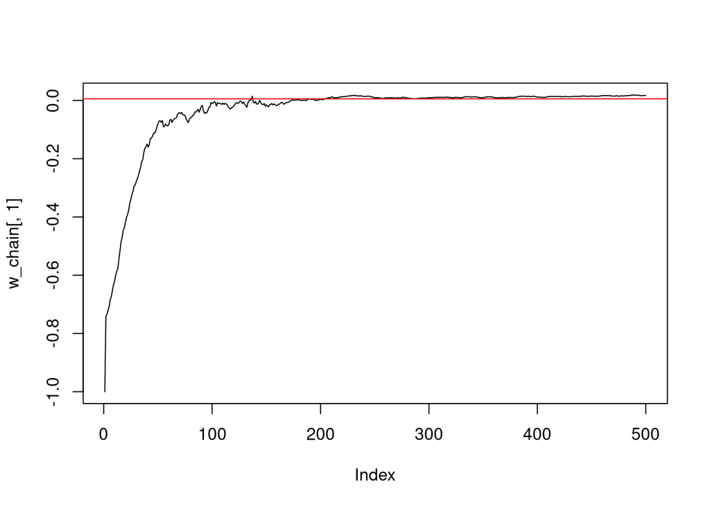

```
## integer(0)
```

```r
plot(w_chain[,1], type='l') +
abline(h=w_true[1], col='red')
```

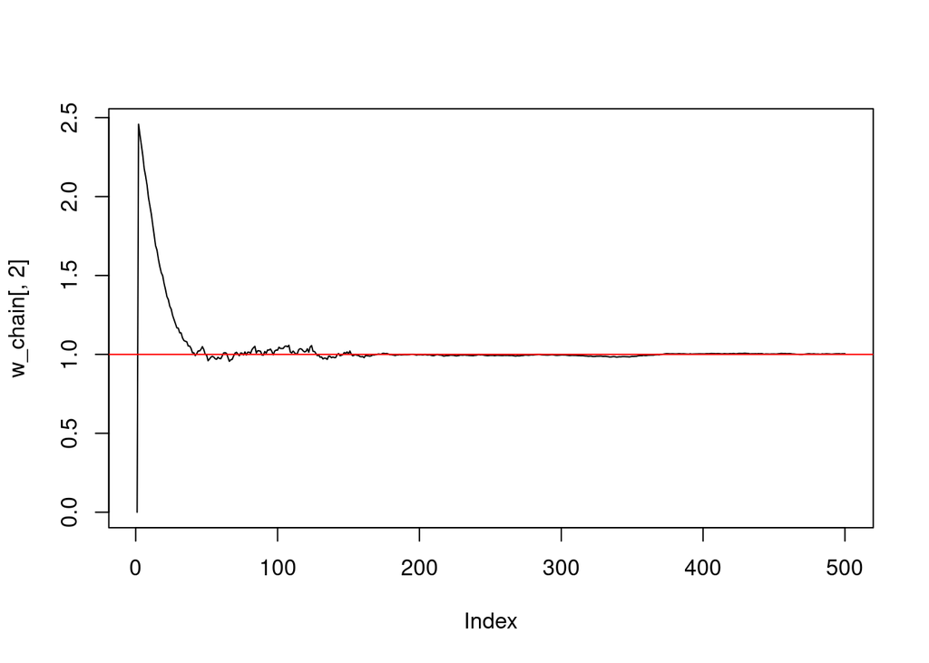

```
## integer(0)
```

```r
#
plot(w_chain[,2], type='l') +
abline(h=w_true[2], col='red')
```

## 1.3 Task

The learning rate can be constant around $C_{0}=10^{-2}$ for the $1/3$ of the run, then it can delay $\varsigma=0.51$ with constant $C_{0}=10^{-2}$, while in the final $1/3$ it can be constant to a small value. (use the aforesaid provided function for the learning rate).

The termination criterion is when the total number of iterations excesses $T_{\text{max}}=500$.

Seed with $w^{(0)}=(-1,0)^\top$.

You may use the R function ‘grad{numDeriv}’ to numerically compute the gradient; e.g. numDeriv::grad( erf_fun, w ) . Try ?grad for more info.

If the gradient explodes apply gradient clipping/scaling with threshold $C=10.0$, as

$$w^{(t+1)}=w^{(t)}+\eta_{t}\left(\text{clip}\left(\frac{n}{m}\sum_{j\in\mathcal{J}^{(t)}}\nabla_{w}\log\left(f\left(z^{(t)}|w^{(t)}\right)\right),c\right)+\nabla_{w}\log\left(f\left(w^{(t)}\right)\right)\right)+\sqrt{\eta_{t}\tau}\epsilon_{t},\,\epsilon_{t}\sim\text{N}\left(0,I\right)$$
where
$$\text{clip}\left(v,c\right)=v\min\left(1,\frac{c}{\left\Vert
v\right\Vert }\right)$$
and $v$ is the gradient.

```r
Tmax <- 500
#
w_seed <- c(-1,0)
#
eta <- 10^(-2)
eta_C <- eta
eta_s <- 0.51
eta_T0 <- 0.3*Tmax
eta_T1 <- 0.6*Tmax
#
batch_size <- 1000
#
tau <- 1.0
#
# Set the seed
w <- w_seed
w_chain_clipping <- c(w)
# iterate
t <- 1
Qterm <- 0
#
clipping_threshold <- 10
#
# iterate
#
while ( (Qterm != 1) ) {
  # counter
  t <- t+1
  cat( t ) ; cat( ' ' ) ## counter added for display reasons
  # learning rate
  eta <- learning_rate(t, eta_T0, eta_T1, eta_C, eta_s)
  # sub-sample
  J <- sample.int( n = n_obs, size = batch_size, replace = FALSE)
  # update
  w_new <- w
  ## likelihood
  grad_est_lik <- rep( 0.0, times=length(w) )
  for (j in J) {
    aux_fun <- function(w, z=z_obs[j,]){
      gr <- log_sampling_pdf(z, w)
      return(gr)
    }
    grad_est_lik <- grad_est_lik + numDeriv::grad(aux_fun, w)
  }
  grad_est_lik <- ( n_obs / batch_size) * grad_est_lik
  # gradient clipping/rescaring
  norm_grad_est_lik <- sqrt(sum(grad_est_lik^2))
  grad_est_lik <- grad_est_lik * min( 1.0, clipping_threshold/norm_grad_est_lik )
  w_new <- w_new +eta*grad_est_lik ;
  ## prior
  aux_fun <- function(w){
    d <- length(w)
    gr <- log_prior_pdf(w, rep(0,d), 100*diag(d))
    return(gr)
  }
  w_new <- w_new +eta*numDeriv::grad(aux_fun, w) ;
  ## noise
  w_new <- w_new +sqrt(2.0)*sqrt(eta)*sqrt(tau)*rnorm(n = length(w), mean = 0, sd = 1)
  # record
  w <- w_new
  # termination criterion
  if  ( t >= Tmax ) {
    Qterm <- 1
  }
  # record the produced chain
  w_chain_clipping <- rbind(w_chain_clipping,w)
}
```

```
## 2 3 4 5 6 7 8 9 10 11 12 13 14 15 16 17 18 19 20 21 22 23 24 25 26 27 28 29 30 31 32 33 34 35 36 37 38 39 40 41 42 43 44 45 46 47 48 49 50 51 52 53 54 55 56 57 58 59 60 61 62 63 64 65 66 67 68 69 70 71 72 73 74 75 76 77 78 79 80 81 82 83 84 85 86 87 88 89 90 91 92 93 94 95 96 97 98 99 100 101 102…
```

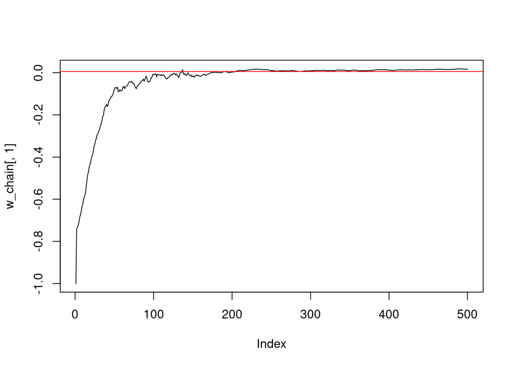

```
## integer(0)
```

```r
plot(w_chain[,1], type='l') +
abline(h=w_true[1], col='red')
```

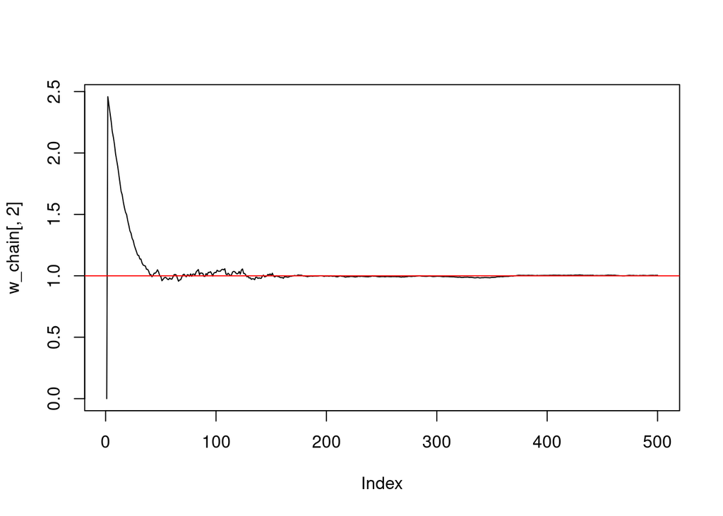

```
## integer(0)
```

```r
#
plot(w_chain[,2], type='l') +
abline(h=w_true[2], col='red')
```

## 1.4 Task

Let’s go back to the code without using the clipping gradient.

Based on the above, copy the tail end of the generated chain $w^(t)$ after discarding the burn in, as ‘w_chain_output’.

```r
T_bunrin <- as.integer(0.6*Tmax)
w_chain_output <- w_chain[T_bunrin:Tmax,]
```

## 1.5 Task

Plot the histograms plots of output chains $\{w_1^{(t)}\}$ and $\{w_2^{(t)}\}$ for the estimation of the marginal posterior distributions of the dimensions of $w$.

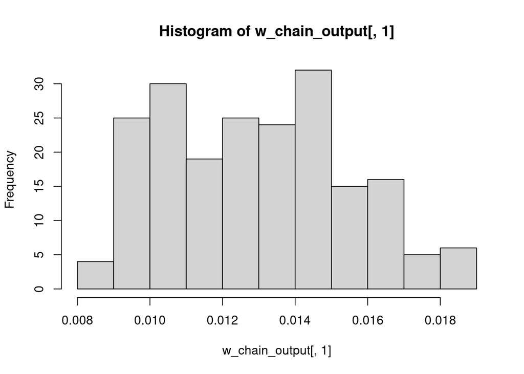

```r
hist(w_chain_output[,1])
```

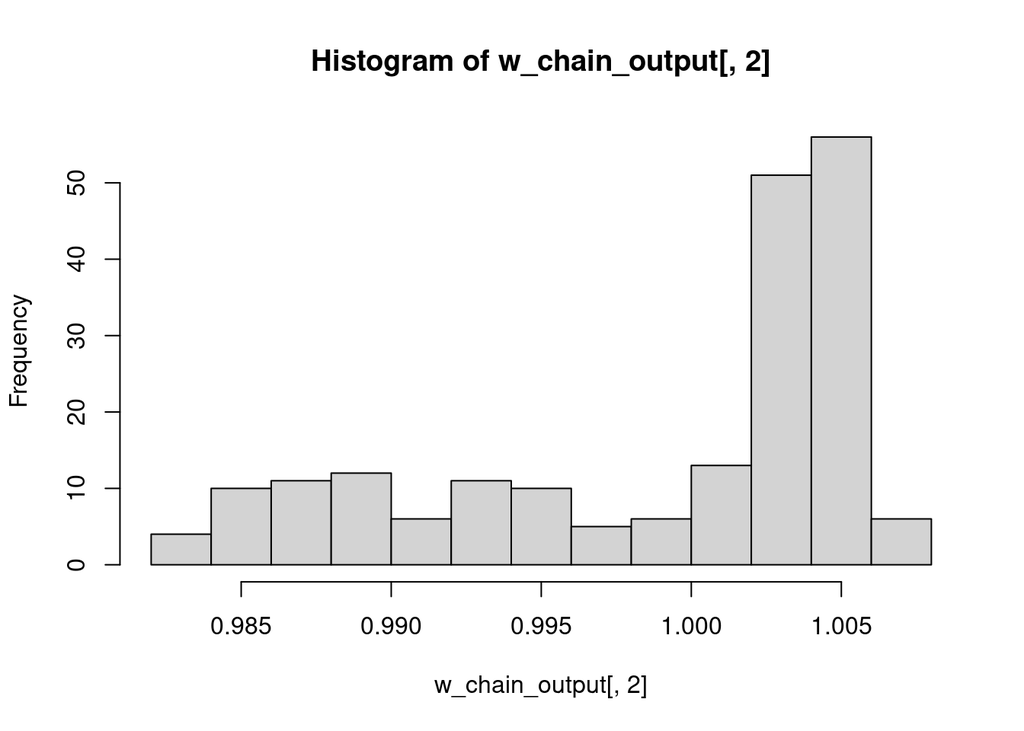

```r
#
hist(w_chain_output[,2])
```

## 1.6 Task

To learn $\text{E}_{f}\left(w_{1}+w_{2}|y\right)$, compute the estimator

$$\widehat{w_{1}+w_{2}}=\frac{1}{T}\sum_{t=1}^{T}\left(w_{1}^{(t)}+w_{2}^{(t)}\right)$$

based on SGLD output chain.

```r
w_est = mean(rowSums(w_chain_output))
w_est
```

```
## [1] 1.011902
```

## 1.7 Task

Use the prediction rule

$$h_{w}\left(x\right)=\frac{\exp\left(x^{\top}w\right)}{1+\exp\left(x^{\top}w\right)}$$

and the estimates for $w$ in order to classify the example with feature $x_\text{new}=c(1, 0.5)$.

Particularly, compute the point estimate

$$\widehat{h_{w}\left(x\right)}=\frac{1}{T}\sum_{t=1}^{T}h_{w^{(t)}}\left(x\right)=\frac{1}{T}\sum_{t=1}^{T}\frac{\exp\left(x^{\top}w^{(t)}\right)}{1+\exp\left(x^{\top}w^{(t)}\right)}$$

```r
x_new <- c(1,0.5)
T <- dim(w_chain_output)[1]
h_est <- 0.0
for (t in 1:T) {
  h_est <- h_est + prediction_rule( x_new , w_chain_output[t,] )
}
h_est <- h_est / T
h_est
```

```
## [1] 0.625371
```

Now, compute the point estimate

$$\widehat{h_{w}\left(x\right)}=h_{\hat{w}}\left(x\right)=\frac{\exp\left(x^{\top}\hat{w}\right)}{1+\exp\left(x^{\top}\hat{w}\right)}$$

by just plugin in the estimate $\hat{w}$.

```r
x_new <- c(1,0.5)
w_est <- colMeans(w_chain_output)
h_est <- prediction_rule( x_new , w_est )
h_est
```

```
## [1] 0.6253719
```

Now, estimate the pdf of the prediction rule at the example with feature $x_\text{new}=c(1, 0.5)$ (to represent the uncertainty) by using a histogram

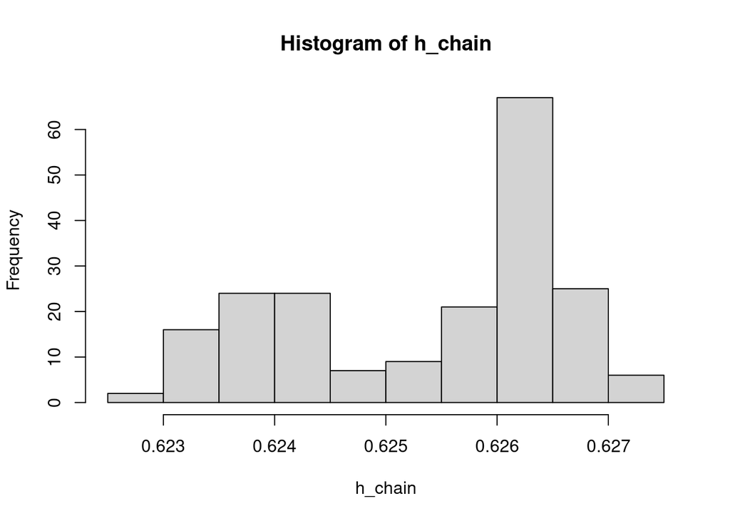

```r
x_new <- c(1,0.5)
T <- dim(w_chain_output)[1]
h_chain <- c()
for (t in 1:T) {
  h_chain <- c( h_chain ,
                prediction_rule( x_new , w_chain_output[t,] )
                )
}
hist(h_chain)
```

## 1.8 Additional tasks

### 1.8.1 Normal mixture model

This task is given as a supplementary material, for your information and your practice.

What happens when the learning problem is non convex? Aka where there are multiple modes (maxima) (true values) in the posterior distribution?

You will see that you will not be able to visit both of the models (maxima) with one run.

- [LINK TO TASKS](http://htmlpreview.github.io/?https://github.com/georgios-stats/Machine_Learning_and_Neural_Networks_III_Epiphany_2024/blob/main/Computer_practical/Stochastic_gradient_langevin_dynamics_NMM_tasks.nb.html)
- [LINK TO SOLUTIONS](http://htmlpreview.github.io/?https://github.com/georgios-stats/Machine_Learning_and_Neural_Networks_III_Epiphany_2024/blob/main/Computer_practical/Stochastic_gradient_langevin_dynamics_NMM_solutions.nb.html)